# Data Lab 8 Modelling Space-Time Areal Data

# 8.1 Data Wrangling and Visualization

Specify working directory and load R data file. The dataframe contains annual cases of chlamydia for 18 years (2002 to 2019) for each of the 159 county in Georgia. The rate is also given per 100,000 people.

```r
setwd ("Y:/Teaching/Bios737 Spatial Analysis/Lectures/SISMID Labs/P8")
load ("Chlamydia_GA.RData")
str (dat)
```

```
## 'data.frame':    2862 obs. of  6 variables:
##  $ County: chr  "Appling County, GA" "Atkinson County, GA" "Bacon County, GA" "Baker County, GA" ...
##  $ FIPS  : int  13001 13003 13005 13007 13009 13011 13013 13015 13017 13019 ...
##  $ Year  : int  2002 2002 2002 2002 2002 2002 2002 2002 2002 2002 ...
##  $ Cases : int  79 20 27 24 269 23 92 146 91 32 ...
##  $ Pop   : num  18347 8339 11083 3799 46186 ...
##  $ Rate  : num  431 240 244 632 582 ...
```

To create year-specific chloropleth maps, we will first create an sf object that will replicate the polygons. Then we will merge the dataset by county ID and year. To better visualize temporal trend, we will use a *spaghetti* plot.

```r
library (sf)
```

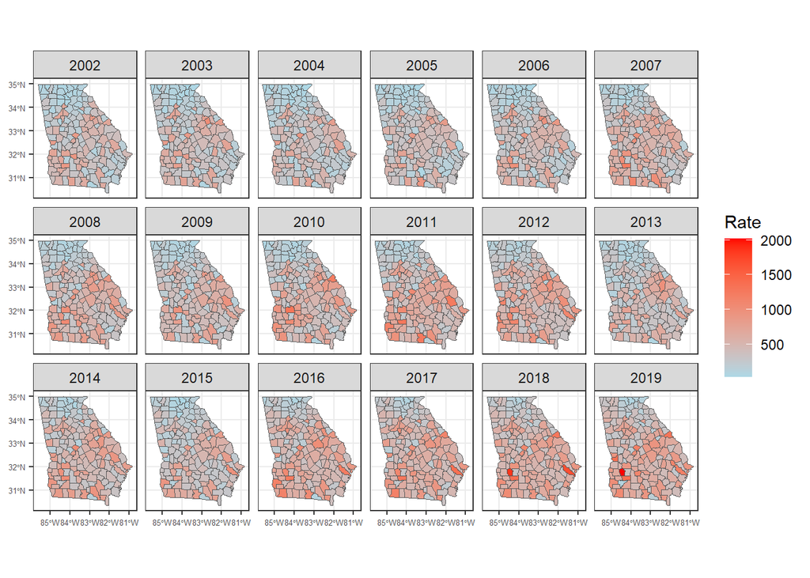

```r
library (maps)
library (stringr)

#Get GA county polygon and create FIPS ID
county.map = map ("county", region = c("georgia"),fill = T,  plot = F)
county.map = sf::st_as_sf(county.map) #Convert from map object to sf
data (county.fips) #Load county 5-digit FIPS code
county.map$FIPS = county.fips$fips[ match (county.map$ID, county.fips$polyname)]
county.map$FIPS =  str_pad (county.map$FIPS, 5, "left", "0")

#Replicate the map polygons 18 times
#First create a list. Then stack by row.
dat.map = vector ("list", 18)
for (i in 1:18){
  dat.map[[i]] = county.map
  dat.map[[i]]$Year = 2001+i
}
dat.map = do.call(rbind, dat.map[])

#Merge with chlamydia data by county FIPS and year
dat.map = merge (dat.map, dat, by = c("FIPS", "Year"))

#Finally, the chlorepleth map.
library (ggplot2)
ggplot (dat.map) + geom_sf (aes (fill=Rate))+ facet_wrap (~Year, ncol = 6)+
  scale_fill_gradient(low = "lightblue",high = "red",)+theme_bw()+theme(axis.text=element_text(size=5))
```

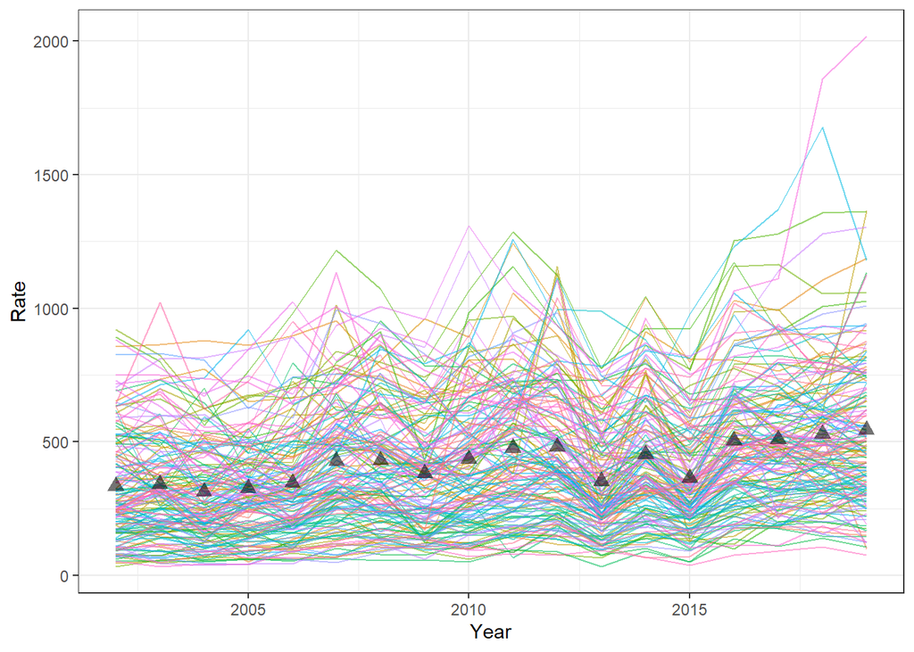

```r
#Spaghetti plot for trend. We will also add the mean rates across counties for each year. We see a large between-county variability and there is a sharp increase in recent years, especially among a few counties.
p = ggplot (data=dat.map, aes(Year, Rate, color = FIPS, alpha = 0.01))
p + geom_line()+guides (color = "none", alpha = "none")+theme_bw()+
   stat_summary(aes(group = 1), geom = "point", fun.y = mean, shape = 17, size = 3)
```

# 8.2 Mixed effect model

We will first fit standard *random intercept* models by assuming additive spatial (county-specific) and temporal (year-specific) deveiations from the mean. These random effects are also assumed to independent of each other. We will again use INLA and you can use the *summary ()* funciton to get estimated parameters from each model.

```r
library (INLA)
```

[output not shown]

```
## This is INLA_23.06.29 built 2023-06-30 04:18:35 UTC.
##  - See www.r-inla.org/contact-us for how to get help.
```

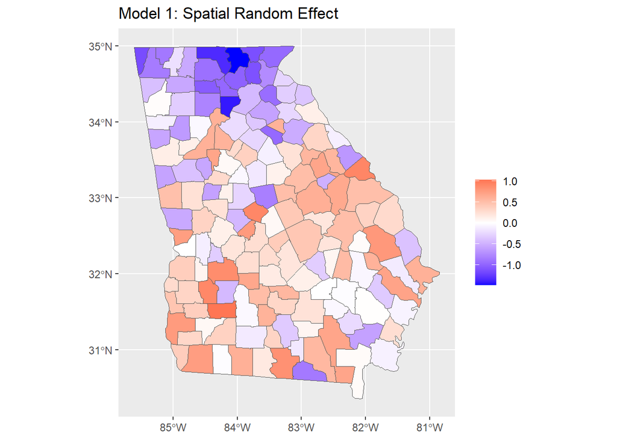

```r
#Work with centered year and by decade to help with intepretation and model fitting
dat$Year_cen = (dat$Year - 2002)/10

## A set of common parameters for INLA
inla.control = list (dic = TRUE,waic = TRUE, cpo = TRUE, return.marginals.predictor=TRUE)

## Create spatial and temporal ID (1, 2, ... etc)
dat$ID_space = as.numeric (factor (dat$FIPS))
dat$ID_time = as.numeric (factor (dat$Year))

#Use population as offset
fit1 = inla (Cases~1+Year_cen + f(ID_space, model = "iid"), E= Pop, family = "poisson", data = dat,                  control.compute = inla.control)

fit2 = inla (Cases~1+Year_cen + f(ID_space, model = "iid")+f(ID_time, model="iid"), E= Pop, family = "poisson", data = dat,control.compute = inla.control)

#Compare the spatial random effects estimated
ggplot () + geom_sf (data = county.map, aes (fill = fit1$summary.random[[1]]$mean))+
  scale_fill_gradient2(low = "blue",high = "red", name = "")+ggtitle("Model 1: Spatial Random Effect")
```

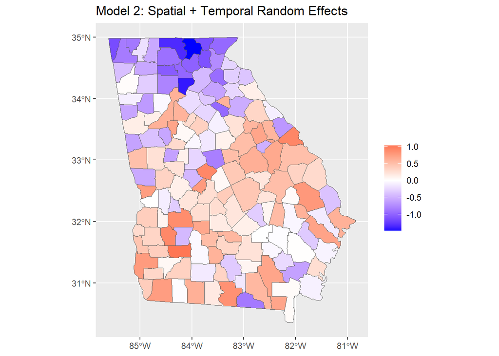

```r
ggplot () + geom_sf (data = county.map, aes (fill = fit2$summary.random$ID_space$mean))+
  scale_fill_gradient2(low = "blue",high = "red", name = "")+ggtitle("Model 2: Spatial + Temporal Random Effects")
```

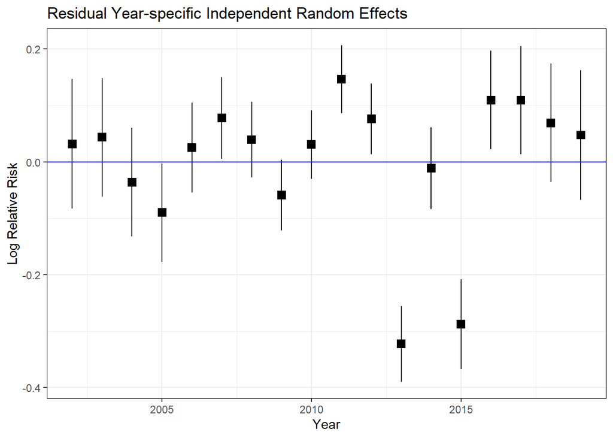

```r
#Here we extract the temporal random effect (year)
ggplot (fit2$summary.random$ID_time) + geom_point(aes(y=mean, x = 2002:2019), shape=15, size=3) +
  geom_linerange(aes(ymin=`0.025quant`, ymax=`0.975quant`, x= 2002:2019)) +
  theme_bw()+ geom_hline(yintercept=0, col = "blue")+xlab("Year") + ylab("Log Relative Risk")+
  ggtitle("Residual Year-specific Independent Random Effects")
```

# 8.3 Additive Spatially and Temporally-Dependent Random Effects

Next we will extend the additive random effects to spatially dependent (via CAR model) or temporally dependent (via random-walk). We again need to create adjancy information (first-order spatial neighborhood) and space/time IDs for INLA.

```r
library (spdep)
```

```
## To access larger datasets in this package, install the spDataLarge
## package with: `install.packages('spDataLarge',
## repos='https://nowosad.github.io/drat/', type='source')`
```

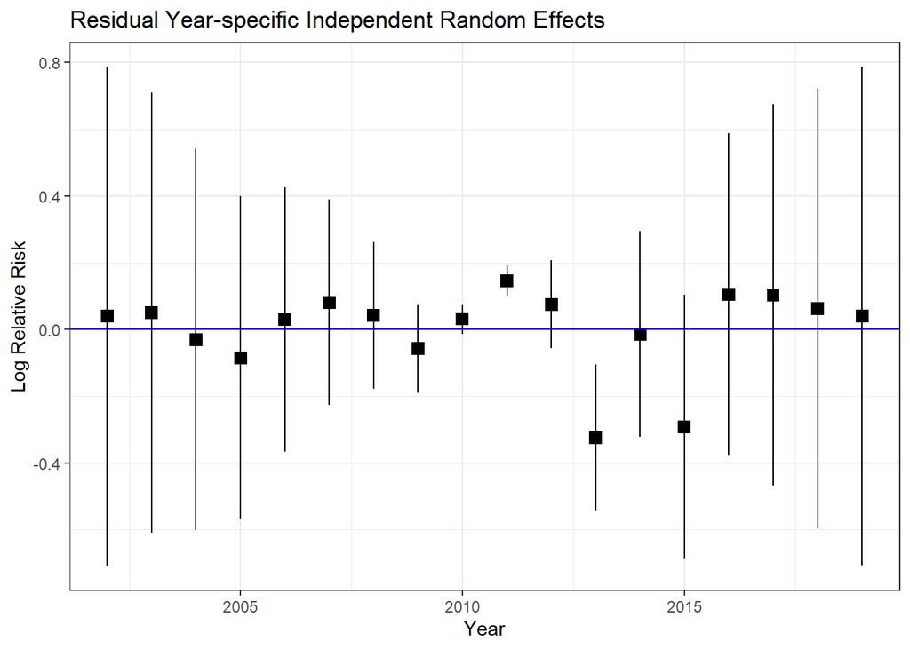

```r
dat_proj = st_transform(county.map, crs = "ESRI:102004")
nb = poly2nb (dat_proj)
nb2INLA ("adj.txt", nb) #write out a file
G <- inla.read.graph(filename = "adj.txt") #read in to get INLA's graph format

dat$ID_space = as.numeric (factor (dat$FIPS))
dat$ID_space_2 = dat$ID_space
dat$ID_time = as.numeric (factor (dat$Year))

#Besag + RW-1
fit3 = inla (Cases~1+Year_cen + f(ID_space, model = "besag", graph = G)  +
               f(ID_time, model = "rw1"),
             E= Pop, family = "poisson", data = dat, control.compute = inla.control)

#Convolution (BYM) + RW-1
fit4 = inla (Cases~1+Year_cen + f(ID_space, model = "besag", graph = G) +  f(ID_space_2) +
               f(ID_time, model = "rw1"), E= Pop, family = "poisson", data = dat, control.compute = inla.control)

#Besag + RW-2
fit5 = inla (Cases~1+Year_cen + f(ID_space, model = "besag", graph = G)  +
               f(ID_time, model = "rw2"), E= Pop, family = "poisson", data = dat, control.compute = inla.control)

#Convolution (BYM) + RW-2
fit6 = inla (Cases~1+Year_cen + f(ID_space, model = "besag", graph = G) +  f(ID_space_2) +
               f(ID_time, model = "rw2"), E= Pop, family = "poisson", data = dat, control.compute = inla.control)

#We see that the estimated temporal random effects have very large uncertainties at the end and not very smooth.
ggplot (fit3$summary.random$ID_time) + geom_point(aes(y=mean, x = 2002:2019), shape=15, size=3) +
  geom_linerange(aes(ymin=`0.025quant`, ymax=`0.975quant`, x= 2002:2019)) +
  theme_bw()+ geom_hline(yintercept=0, col = "blue")+xlab("Year") + ylab("Log Relative Risk")+
  ggtitle("Residual Year-specific Independent Random Effects")
```

# 8.4 Space-time Interactions

To allow for time-specific spatial effects, we use the *group* option in specifying the spatial random effects. The dependency structure across group (i.e., year) can be specified as a separable covariance structure. These models take a bit longer to fit.

```r
dat$ID_space_time = 1:nrow (dat)

#A model with iid space-time interaction random effects
fit7 = inla (Cases~1+Year_cen + f(ID_space, model = "besag", graph = G) +  f(ID_space_time) +
               f(ID_time), E= Pop, family = "poisson", data = dat, control.compute = inla.control)


#Independent across time
fit8 = inla (Cases~1+Year_cen + f(ID_space, model = "besag", graph = G, group = ID_time, control.group = list(model = "iid")) + f(ID_time),  E= Pop, family = "poisson", data = dat, control.compute = inla.control)

#Exchangeable across time
fit9 = inla (Cases~1+Year_cen + f(ID_space, model = "besag", graph = G, group = ID_time, control.group = list(model = "exchangeable")) + f(ID_time),  E= Pop, family = "poisson", data = dat, control.compute = inla.control)

#Dynamic (Autoregressive order-1)
fit10 = inla (Cases~1+Year_cen + f(ID_space, model = "besag", graph = G, group = ID_time, control.group = list(model = "ar1")) + f(ID_time),  E= Pop, family = "poisson", data = dat, control.compute = inla.control)
```